# LESSON 1: PYTHON INTRODUCTION

[figure not shown]

## 1. Overall introduction

"Python is a programming language that lets you work more quickly and integrate your systems more effectively."

### Python is popular

- Simple in syntax
- Close to the English language  
  => Read and understand easily

The 4th industrial revolution makes Cloud Computing, Machine Learning, and Big Data become hot trend. And Python allows professionals to

- conduct complex statistical calculations
- create data visualizations
- build machine learning algorithms
- manipulate and analyze data
- ...

[figure not shown]

### Python has lots of applications

- Web and Internet Development
- Database Access
- Desktop GUIs
- Scientific & Numeric
- Education
- Network Programming
- Software & Game Development

### Python is easy to learn

- Active community which hosts conferences and meetups, collaborates on code, and much more.
- Python document is open and easy to understand ([link](https://docs.python.org/3/library/)).
- Built-in libraries and external libraries are powerful for many tasks, especially for data science, data engineer and data analysis:
  - Scientific computing: numpy, numba, etc.
  - AWS interaction: boto3
  - Image processing: opencv, pillow, albumentation, etc.
  - Machine learning and Deep learning framework: tensorflow, pytorch, onnx, sklearn, etc.
  - Data processing and visualization: pandas, pyyaml, matplotlib, seaborn etc.

```python
print('Hello world!!!')
```

```
Hello world!!!
```

## 2. Import Python library

### 2.1. Import internal library

Internal library is the built-in library which installed while installing Python.

```python
import math
import json
import os
```

```python
print(math.pi)
```

```
3.141592653589793
```

### 2.2. Import external library

External library is the library developed by community and have to be installed independently with Python.

```python
import numpy
import pandas
import matplotlib
```

```python
# Error while import library that haven't been installed
import torch
```

```
---------------------------------------------------------------------------
ModuleNotFoundError                       Traceback (most recent call last)
<ipython-input-4-157778a9721e> in <module>
      1 # Error while import library that haven't been installed
----> 2 import torch

ModuleNotFoundError: No module named 'torch'
```

### 2.3. Import specific modules from a library

```python
from math import pi
```

```python
print(pi)
```

```
3.141592653589793
```

```python
from math import pi, e
```

```python
print(pi)
print(e)
```

```
3.141592653589793
2.718281828459045
```

### 2.4. Import all modules from a library

```python
from math import *
```

```python
print(pi)
print(e)
```

```
3.141592653589793
2.718281828459045
```

### 2.5. Set module alias while importing

```python
from math import pi as pi_number
```

```python
print(pi_number)
```

```
3.141592653589793
```

```python
from math import pi as pi_number, e as e_number
```

```python
print(pi_number)
print(e_number)
```

```
3.141592653589793
2.718281828459045
```

## 3. Introduce to Python comment

In order to note and explain the code, comment is an important part in each programming language.  
Each code starts with `#` will be a comment and the compiler will ignore all of them.

```python
# this is a comment
# Python comment starts with `#`

a = 1 # Assign `a` by value `1`
b = 'MCI Python level 1' # `b` is a string
```

We can write a comment in multiple lines by using `'''this is a multi-line comment'''` or `"""this is a comment in multiple lines"""`. Originally, `''' '''` and `""" """` stand for Python string in multiple lines, but we only write these strings and don't assign them for any variable, these strings can another type of comment.

```python
'''
this is
a multi-line comment
'''

a = 1 # Assign `a` by value `1`
b = 'MCI Python level 1' # `b` is a string
```

```python
"""
this is
another multi-line comment
"""

a = 1 # Assign `a` by value `1`
b = 'MCI Python level 1' # `b` is a string
```

We can use the shortcut `Ctrl + /` on Windows and Ubuntu or `Cmd + /` on MacOS to make a line of code become a comment.

## 4. Introduce to Python variable

With Python, we don't need to define the data type of a variable, the compiler will automatically understand based on the value of variable.

### 4.1. Assign value to variable

The simplest way to assign `a value` to `a variable` is using `=`. `=` means `assign`, not `equal`.

```python
a = 'MCI Python level 1'
b = 123
c = 456.789
```

```python
print(a)
```

```
MCI Python level 1
```

```python
print(b)
```

```
123
```

```python
print(c)
```

```
456.789
```

We can assign `multiple values` to `multiple variables` in one line of code.  
The first way:

```python
a, b, c = 'MCI Python level 1', 123, 456.789
```

```python
print(a)
```

```
MCI Python level 1
```

```python
print(b)
```

```
123
```

```python
print(c)
```

```
456.789
```

The second way:

```python
a = 'MCI Python level 1'; b = 123; c = 456.789
```

```python
print(a)
```

```
MCI Python level 1
```

```python
print(b)
```

```
123
```

```python
print(c)
```

```
456.789
```

We can assign a value to multiple variables

```python
a = b = c = 456.789
```

```python
print(a)
```

```
456.789
```

```python
print(b)
```

```
456.789
```

```python
print(c)
```

```
456.789
```

### 4.2. Name the variable

Some rules while naming Python variable:

- Python variable name can contain only `alphabet a-z A-Z`, `digit 0-9` and `underscore _`, cannot contain special character `! @ # $ % ^ & * ( ) - = + { } : " ; , . / ?`
- Python variable name cannot start with a `digit`, it can only start with `alphabet` or `underscore`.  
  Example: `1abc` is bad name, `abc1` and `_1abc` are good names.
- Python variable name is case-sentitive.  
  Example: `abc`, `Abc`, `aBC` are different variables.

```python
1abc = 1
```

```
  File "<ipython-input-18-f1224379a134>", line 1
    1abc = 1
     ^
SyntaxError: invalid syntax
```

```python
abc1 = 1
```

```python
_1abc = 1
```

```python
abc = 1
Abc = 2
aBC = 3

print('abc = ', abc)
print('Abc = ', Abc)
print('aBC = ', aBC)
```

```
abc =  1
Abc =  2
aBC =  3
```

Some styles while naming Python variable:

- Camel Case: the first character of each word is upper-case (except the first word)
  - myHouse
  - dogName
  - myVariableName
- Pascal Case: the first character of each word is upper-case (include the first word)
  - MyHouse
  - DogName
  - MyVariableName
- Snake Case: each word in variable will be separated by the underscore _
  - my_house
  - dog_name
  - my_variable_name
- Or, we can mix these above styles

## 5. Introduce to Python data types

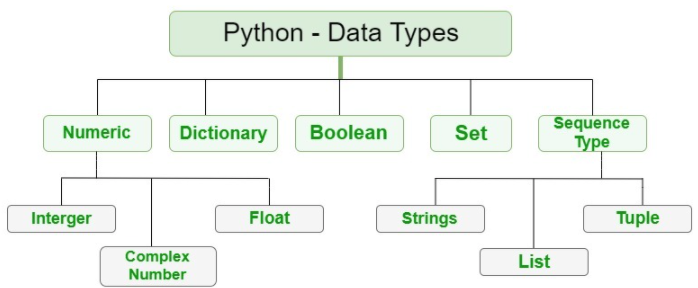

### 5.1. Get variable data type

To get the data type of a variable, we use function `type()`.

```python
a = 1

print('a = ', a, type(a))
```

```
a =  1 <class 'int'>
```

```python
b = 15.11

print('b = ', b, type(b))
```

```
b =  15.11 <class 'float'>
```

```python
c = 'MCI Python Level 1'

print('c = ', c, type(c))
```

```
c =  MCI Python Level 1 <class 'str'>
```

### 5.2. Numeric type: Integer (int) and Float (float)

Integer and Float are simple data type in lots of programming language.

```python
d = 1
print('d = ', d)
print('type of d: ', type(d))
```

```
d =  1
type of d:  <class 'int'>
```

```python
e = 0.5555
print('e = ', e)
print('type of e: ', type(e))
```

```
e =  0.5555
type of e:  <class 'float'>
```

```python
f = 1.
print('f = ', f)
print('type of f: ', type(f))
```

```
f =  1.0
type of f:  <class 'float'>
```

### 5.3. Boolean type: Bool

Bool is logical data type (True/False)

```python
g = True
print('g = ', g)
print('type of g: ', type(g))
```

```
g =  True
type of g:  <class 'bool'>
```

```python
h = False
print('h = ', h)
print('type of h: ', type(h))
```

```
h =  False
type of h:  <class 'bool'>
```

### 5.4. Sequence type: String (str)

#### Define a String

The string in Python is define by using `' '` and `" "`.  
Example: `'this is a string in Python'` or `"MCI Python level 1"`

```python
a = 'this is a string in Python'
print('a = ', a)
print('type of a: ', type(a))
```

```
a =  this is a string in Python
type of a:  <class 'str'>
```

```python
b = "MCI Python level 1"
print('b = ', b)
print('type of b: ', type(b))
```

```
b =  MCI Python level 1
type of b:  <class 'str'>
```

We can define a string in multiple lines by using `''' '''` and `""" """`.  
Example:

```
'''this is a string
in Python'''
```

or

```
"""MCI Python
level 1"""
```

```python
a = '''this is a string
in Python'''
print('a = ', a)
print('type of a: ', type(a))
```

```
a =  this is a string
in Python
type of a:  <class 'str'>
```

```python
b = """MCI Python
level 1"""
print('b = ', b)
print('type of b: ', type(b))
```

```
b =  MCI Python
level 1
type of b:  <class 'str'>
```

#### Get the String length

We can get length of the string by using function `len()`

```python
a = 'this is a string in Python'
print('a = ', a)
print('len of a: ', len(a))
```

```
a =  this is a string in Python
len of a:  26
```

#### Slice and Index the String

We can access every character in a string by its `index` (`index` means the position, from 0 to the length - 1).

```python
a = 'MCI Python level 1'
print(a)
print(len(a))
```

```
MCI Python level 1
18
```

```python
print(a[0])
```

```
M
```

```python
print(a[1])
```

```
C
```

```python
print(a[10])
```

```python
print(a[17])
```

```
1
```

We can use negative index to access character from the end of a string

```python
a = 'MCI Python level 1'
print(a)
print(len(a))
```

```
MCI Python level 1
18
```

```python
print(a[-1])
```

```
1
```

```python
print(a[-2])
```

```python
print(a[-10])
```

```
o
```

```python
print(a[-18])
```

```
M
```

We can slice a part of a string by using `index` and `:`

```python
a = 'MCI Python level 1'
print(a)
print(len(a))
```

```
MCI Python level 1
18
```

```python
print(a[0:3])
```

```
MCI
```

```python
print(a[4:10])
```

```
Python
```

```python
print(a[-7:-1])
```

```
level
```

```python
print(a[:10])
```

```
MCI Python
```

```python
print(a[-7:])
```

```
level 1
```

We use only integer as index of a string (not float, not string)

```python
print(a[1])
```

```
C
```

```python
print(a[1.])
```

```
---------------------------------------------------------------------------
TypeError                                 Traceback (most recent call last)
<ipython-input-25-131ef13a6327> in <module>
----> 1 print(a[1.])

TypeError: string indices must be integers
```

```python
print(a['1'])
```

```
---------------------------------------------------------------------------
TypeError                                 Traceback (most recent call last)
<ipython-input-26-b67e9b4cfda0> in <module>
----> 1 print(a['1'])

TypeError: string indices must be integers
```

#### Functions to modify string

Function `upper()` makes all character become upper-case.

```python
print(a)
```

```
MCI Python level 1
```

```python
a_upper = a.upper()
print(a_upper)
```

```
MCI PYTHON LEVEL 1
```

Function `lower()` makes all character become lower-case.

```python
print(a)
```

```
MCI Python level 1
```

```python
a_lower = a.lower()
print(a_lower)
```

```
mci python level 1
```

Function `replace()` replaces a sub-string by a new string.

```python
print(a)
```

```
MCI Python level 1
```

```python
a_replace = a.replace('Python', 'Excel')
print(a_replace)
```

```
MCI Excel level 1
```

Function `split()` splits an original string into a list of sub-string by a string.

```python
print(a)
```

```
MCI Python level 1
```

```python
a_split_1 = a.split(' ')
print(a_split_1)
```

```
['MCI', 'Python', 'level', '1']
```

```python
a_split_2 = a.split('e')
print(a_split_2)
```

```
['MCI Python l', 'v', 'l 1']
```

#### String format

We can combine other data type variable to print out with string format.  
Use simple `format()` function:

```python
level = 1

a = 'MCI Python level {}'.format(level)
print(a)
```

```
MCI Python level 1
```

```python
level = 1
course = 'Python'

a = 'MCI {} level {}'.format(course, level)
print(a)
```

```
MCI Python level 1
```

Use `format()` function with the index:

```python
num_1 = 15
num_2 = 4
```

```python
a = 'Sum of {} and {} is equal to {}'.format(num_1, num_2, num_1 + num_2)
print(a)
```

```
Sum of 15 and 4 is equal to 19
```

```python
a = 'Sum of {0} and {1} is equal to {2}'.format(num_1, num_2, num_1 + num_2)
print(a)
```

```
Sum of 15 and 4 is equal to 19
```

```python
a = 'Sum of {1} and {2} is equal to {0}'.format(num_1 + num_2, num_1, num_2)
print(a)
```

```
Sum of 15 and 4 is equal to 19
```

From Python 3.6, we can use `f-string` instead of `format()`

```python
a = f'Sum of {num_1} and {num_2} is equal to {num_1 + num_2}'
print(a)
```

```
Sum of 15 and 4 is equal to 19
```

### 5.5. Sequence type: List

List is data type which contains lots of variables, variables in list can be in different data types (including another list).

#### Define a List

To define a list, we use `[` and `]` bracket.

```python
u = [1, 2.5, 3, 'stringgg', -20, 'Minh']
print('u = ', u)
print('type of u: ', type(u))
```

```
u =  [1, 2.5, 3, 'stringgg', -20, 'Minh']
type of u:  <class 'list'>
```

```python
v = [1.504, ['MCI', 3], 'Python', True]
print('v = ', v)
print('type of v: ', type(v))
```

```
v =  [1.504, ['MCI', 3], 'Python', True]
type of v:  <class 'list'>
```

#### Get the List length

Like String, we use function `len()` to get the length of a list.

```python
print(len(u))
```

```
6
```

```python
print(len(v))
```

```
4
```

#### Slice and Index the List

We can access every character in a list by its `index` (`index` means the position, from 0 to the length - 1).

```python
print(u)
print(len(u))
```

```
[1, 2.5, 3, 'stringgg', -20, 'Minh']
6
```

```python
print(u[0])
```

```
1
```

```python
print(u[2])
```

```
3
```

```python
print(v)
print(len(v))
```

```
[1.504, ['MCI', 3], 'Python', True]
4
```

```python
print(v[1])
```

```
['MCI', 3]
```

```python
print(v[2])
```

```
Python
```

We can use negative index to access character from the end of a list

```python
print(u)
```

```
[1, 2.5, 3, 'stringgg', -20, 'Minh']
```

```python
print(u[-1])
```

```
Minh
```

```python
print(u[-3])
```

```
stringgg
```

```python
print(v)
```

```
[1.504, ['MCI', 3], 'Python', True]
```

```python
print(v[-2])
```

```
Python
```

```python
print(v[-3])
```

```
['MCI', 3]
```

We can slice a part of a list by using `index` and `:`

```python
print(u)
print(len(u))
```

```
[1, 2.5, 3, 'stringgg', -20, 'Minh']
6
```

```python
print(u[0:4])
```

```
[1, 2.5, 3, 'stringgg']
```

```python
print(u[2:6])
```

```
[3, 'stringgg', -20, 'Minh']
```

```python
print(u[-4:-1])
```

```
[3, 'stringgg', -20]
```

```python
print(u[:4])
```

```
[1, 2.5, 3, 'stringgg']
```

```python
print(u[-3:])
```

```
['stringgg', -20, 'Minh']
```

We use only integer as index of a list (not float, not string).

```python
print(u[1.])
```

```
---------------------------------------------------------------------------
TypeError                                 Traceback (most recent call last)
<ipython-input-101-254126a5ba71> in <module>
----> 1 print(u[1.])

TypeError: list indices must be integers or slices, not float
```

```python
print(u['1'])
```

```
---------------------------------------------------------------------------
TypeError                                 Traceback (most recent call last)
<ipython-input-102-d8836870ff35> in <module>
----> 1 print(u['1'])

TypeError: list indices must be integers or slices, not str
```

#### Change the value of elements in List

Change single value

```python
print('List before re-assigning:')
print(u)
```

```
List before re-assigning:
[1, 2.5, 3, 'stringgg', -20, 'Minh']
```

```python
u[0] = 'change the first value'

print('List after re-assigning:')
print(u)
```

```
List after re-assigning:
['change the first value', 2.5, 3, 'stringgg', -20, 'Minh']
```

Change multiple value

```python
print('List before re-assigning:')
print(v)
```

```
List before re-assigning:
[1.504, ['MCI', 3], 'Python', True]
```

```python
v[2:] = ['change value', 'value changed']

print('List after re-assigning:')
print(v)
```

```
List after re-assigning:
[1.504, ['MCI', 3], 'change value', 'value changed']
```

#### Functions to modify List

Function `append()` used to add an element to the last position of a list.

```python
print(u)
print(len(u))
```

```
['change the first value', 2.5, 3, 'stringgg', -20, 'Minh']
6
```

```python
u.append('appended item')

print(u)
print(len(u))
```

```
['change the first value', 2.5, 3, 'stringgg', -20, 'Minh', 'appended item']
7
```

Function `insert()` used to add an element to the specific position of a list.

```python
print(u)
print(len(u))
```

```
['change the first value', 2.5, 3, 'stringgg', -20, 'Minh', 'appended item']
7
```

```python
u.insert(1, 'inserted item')

print(u)
print(len(u))
```

```
['change the first value', 'inserted item', 2.5, 3, 'stringgg', -20, 'Minh', 'appended item']
8
```

Function `extend()` used to concatenate another list to the original list.

```python
print(u)
print(len(u))
```

```
['change the first value', 'inserted item', 2.5, 3, 'stringgg', -20, 'Minh', 'appended item']
8
```

```python
print(v)
print(len(v))
```

```
[1.504, ['MCI', 3], 'change value', 'value changed']
4
```

```python
u.extend(v)

print(u)
print(len(u))
```

```
['change the first value', 'inserted item', 2.5, 3, 'stringgg', -20, 'Minh', 'appended item', 1.504, ['MCI', 3], 'change value', 'value changed']
12
```

Function `remove()` used to remove the specific item in a list.

```python
print(u)
print(len(u))
```

```
['change the first value', 'inserted item', 2.5, 3, 'stringgg', -20, 'Minh', 'appended item', 1.504, ['MCI', 3], 'change value', 'value changed']
12
```

```python
u.remove(2.5)

print(u)
print(len(u))
```

```
['change the first value', 'inserted item', 3, 'stringgg', -20, 'Minh', 'appended item', 1.504, ['MCI', 3], 'change value', 'value changed']
11
```

```python
u.remove('change value')

print(u)
print(len(u))
```

```
['change the first value', 'inserted item', 3, 'stringgg', -20, 'Minh', 'appended item', 1.504, ['MCI', 3], 'value changed']
10
```

Function `pop()` used to remove the specific item in a list by its index.

```python
print(u)
print(len(u))
```

```
['change the first value', 'inserted item', 3, 'stringgg', -20, 'Minh', 'appended item', 1.504, ['MCI', 3], 'value changed']
10
```

```python
u.pop(1)

print(u)
print(len(u))
```

```
['change the first value', 3, 'stringgg', -20, 'Minh', 'appended item', 1.504, ['MCI', 3], 'value changed']
9
```

```python
u.pop(1)

print(u)
print(len(u))
```

```
['change the first value', 'stringgg', -20, 'Minh', 'appended item', 1.504, ['MCI', 3], 'value changed']
8
```

Function `clear()` used to remove all elements in a list.

```python
print(u)
print(len(u))
```

```
['change the first value', 'stringgg', -20, 'Minh', 'appended item', 1.504, ['MCI', 3], 'value changed']
8
```

```python
u.clear()

print(u)
print(len(u))
```

```
[]
0
```

Function `sort()` used to sort a list in a specific order.  
With a list of string, this function will sort a list in alphabet. With a list of number, this function will sort a list ascendingly.  
If we use `sort(reverse=True)`, the order will be reversed.

```python
fruit_list = ["orange", "mango", "kiwi", "pineapple", "banana"]
print(fruit_list)
```

```
['orange', 'mango', 'kiwi', 'pineapple', 'banana']
```

```python
fruit_list.sort()
print(fruit_list)
```

```
['banana', 'kiwi', 'mango', 'orange', 'pineapple']
```

```python
fruit_list.sort(reverse=True)
print(fruit_list)
```

```
['pineapple', 'orange', 'mango', 'kiwi', 'banana']
```

```python
number_list = [1, 8.0, 4.2, 3, 6]
print(number_list)
```

```
[1, 8.0, 4.2, 3, 6]
```

```python
number_list.sort()
print(number_list)
```

```
[1, 3, 4.2, 6, 8.0]
```

```python
number_list.sort(reverse=True)
print(number_list)
```

```
[8.0, 6, 4.2, 3, 1]
```

### 5.6. Sequence type: Tuple

Tuple is data type which contains lots of variables, variables in tuple can be in different data types (including another tuple).

#### Define a Tuple

To define a tuple, we use `(` and `)` bracket.  
To define a tuple with 1 item, we have to put a comma after this item. => this is one difference between `list` and `tuple`.

```python
g = (1, 2.5, 3, 'stringgg')

print('g = ', g)
print('type of g: ', type(g))
```

```
g =  (1, 2.5, 3, 'stringgg')
type of g:  <class 'tuple'>
```

```python
g_1 = ('this is not a tuple')

print('g_1 = ', g_1)
print('type of g_1: ', type(g_1))
```

```
g_1 =  this is not a tuple
type of g_1:  <class 'str'>
```

```python
g_2 = ('this is a tuple',)

print('g_2 = ', g_2)
print('type of g_2: ', type(g_2))
```

```
g_2 =  ('this is a tuple',)
type of g_2:  <class 'tuple'>
```

#### Get the Tuple length

Like String and List, we use function `len()` to get the length of a tuple.

```python
print(len(g))
```

```
4
```

```python
print(len(g_2))
```

```
1
```

#### Slice and Index the Tuple

We can access every character in a tuple by its `index` (`index` means the position, from 0 to the length - 1).

```python
print(g)
print(len(g))
```

```
(1, 2.5, 3, 'stringgg')
4
```

```python
print(g[0])
```

```
1
```

```python
print(g[2])
```

```
3
```

```python
print(g[3])
```

```
stringgg
```

We can use negative index to access character from the end of a tuple.

```python
print(g)
```

```
(1, 2.5, 3, 'stringgg')
```

```python
print(g[-1])
```

```
stringgg
```

```python
print(g[-3])
```

```
2.5
```

We can slice a part of a tuple by using `index` and `:`

```python
print(g)
print(len(g))
```

```
(1, 2.5, 3, 'stringgg')
4
```

```python
print(g[2:4])
```

```
(3, 'stringgg')
```

```python
print(g[0:3])
```

```
(1, 2.5, 3)
```

```python
print(g[-3:-1])
```

```
(2.5, 3)
```

```python
print(g[:2])
```

```
(1, 2.5)
```

```python
print(g[-3:])
```

```
(2.5, 3, 'stringgg')
```

We use only integer as index of a tuple (not float, not string).

```python
print(g[1.])
```

```
---------------------------------------------------------------------------
TypeError                                 Traceback (most recent call last)
<ipython-input-152-4e9678891836> in <module>
----> 1 print(g[1.])

TypeError: tuple indices must be integers or slices, not float
```

```python
print(g['1'])
```

```
---------------------------------------------------------------------------
TypeError                                 Traceback (most recent call last)
<ipython-input-153-096b9bfe9083> in <module>
----> 1 print(g['1'])

TypeError: tuple indices must be integers or slices, not str
```

#### CANNOT change the value of elements in Tuple

```python
print('Tuple `g` before:')
print(g)
print(len(g))
```

```
Tuple `g` before:
(1, 2.5, 3, 'stringgg')
4
```

```python
print(g[0])
```

```
1
```

```python
g[0] = 9999
```

```
---------------------------------------------------------------------------
TypeError                                 Traceback (most recent call last)
<ipython-input-157-9a2fe1c1f043> in <module>
----> 1 g[0] = 9999

TypeError: 'tuple' object does not support item assignment
```

```python
print('Tuple `g` after:')
print(g)
print(len(g))
```

```
Tuple `g` after:
(1, 2.5, 3, 'stringgg')
4
```

### 5.7. Set type: Set

Set is data type which contains lots of variables, variables in set can be in different data types (including another set).

#### Define a Set

To define a list, we use `{` and `}` bracket. Each element in a set is unique.

```python
s = {1, 2, 3}

print('s = ', s)
print('type of s: ', type(s))
```

```
s =  {1, 2, 3}
type of s:  <class 'set'>
```

```python
s = {1, 2, 3, 1}

print('s = ', s)
print('type of s: ', type(s))
```

```
s =  {1, 2, 3}
type of s:  <class 'set'>
```

#### Get the Set length

We use function `len()` to get the length of a set.

```python
print(len(s))
```

```
3
```

#### Access element in Set

The order of elements in set is not guaranteed so we cannot use `index` or `slice` to access item. We can use `for` loop to access elements in set (`for` loop will be introduced in the next lesson)

```python
s[0]
```

```
---------------------------------------------------------------------------
TypeError                                 Traceback (most recent call last)
<ipython-input-134-c9c96910e542> in <module>
----> 1 s[0]

TypeError: 'set' object is not subscriptable
```

```python
for item in s:
    print(item)
```

```
1
2
3
```

#### Functions to modify Set

Function `add()` can be used to add single item to set.

```python
print(s)
print(len(s))
```

```
{1, 2, 3}
3
```

```python
s.add('add first item')

print(s)
print(len(s))
```

```
{1, 2, 3, 'add first item'}
4
```

Function `update()` can be used to add another set or list or tuple to set.

```python
s_1 = {1.1, 2.2, 3.5, 'new set'}

print(s_1)
print(len(s_1))
```

```
{1.1, 2.2, 3.5, 'new set'}
4
```

```python
s.update(s_1)

print(s)
print(len(s))
```

```
{1, 2, 3, 1.1, 2.2, 3.5, 'add first item', 'new set'}
8
```

```python
l_1 = ['item 1 in list', 'item 2 in list']

print(l_1)
print(len(l_1))
```

```
['item 1 in list', 'item 2 in list']
2
```

```python
s.update(l_1)

print(s)
print(len(s))
```

```
{1, 2, 3, 1.1, 2.2, 3.5, 'add first item', 'new set', 'item 2 in list', 'item 1 in list'}
10
```

Another way to combine 2 set is using function `union()`. The difference is, function `union()` creates a new set, function `update()` adds more item into existing set.

```python
print(s)
print(len(s))
```

```
{1, 2, 3, 1.1, 2.2, 3.5, 'add first item', 'new set', 'item 2 in list', 'item 1 in list'}
10
```

```python
s_3 = {'x', 'y', 'z'}

print(s_3)
print(len(s_3))
```

```
{'x', 'z', 'y'}
3
```

```python
new_s = s.union(s_3)

print(new_s)
print(len(new_s))
```

```
{1, 2, 3, 1.1, 2.2, 3.5, 'z', 'add first item', 'x', 'new set', 'item 2 in list', 'item 1 in list', 'y'}
13
```

```python
print(s)
```

```
{1, 2, 3, 1.1, 2.2, 3.5, 'add first item', 'new set', 'item 2 in list', 'item 1 in list'}
```

Function `intersection_update()` and `intersection()` can be used to get the items that appear in both set. While `intersection_update()` update into existing set, `intersection()` creates a new set.

```python
ss_1 = {1, 2, 3}

print(ss_1)
```

```
{1, 2, 3}
```

```python
ss_2 = {2, 4, 6}

print(ss_2)
```

```
{2, 4, 6}
```

```python
new_ss = ss_1.intersection(ss_2)

print(new_ss)
```

```
{2}
```

```python
ss_1.intersection_update(ss_2)

print(ss_1)
```

```
{2}
```

Function `symmetric_difference_update()` and `symmetric_difference()` can be used to get the items that appear in ONLY ONE set. While `symmetric_difference_update()` update into existing set, `symmetric_difference()` creates a new set.

```python
ss_1 = {1, 2, 3}

print(ss_1)
```

```
{1, 2, 3}
```

```python
ss_2 = {2, 4, 6}

print(ss_2)
```

```
{2, 4, 6}
```

```python
new_ss = ss_1.symmetric_difference(ss_2)

print(new_ss)
```

```
{1, 3, 4, 6}
```

```python
ss_1.symmetric_difference_update(ss_2)

print(ss_1)
```

```
{1, 3, 4, 6}
```

Function `remove()` and `discard()` can be used to remove an item from a set. But, if the removed item is not in set, function `remove()` will raise an error, function `discard()` will not raise an error.

```python
print(s)
print(len(s))
```

```
{1, 2, 3, 1.1, 2.2, 3.5, 'add first item', 'new set', 'item 2 in list', 'item 1 in list'}
10
```

```python
s.remove(1)

print(s)
print(len(s))
```

```
{2, 3, 1.1, 2.2, 3.5, 'add first item', 'new set', 'item 2 in list', 'item 1 in list'}
9
```

```python
s.remove(999)
```

```
---------------------------------------------------------------------------
KeyError                                  Traceback (most recent call last)
<ipython-input-185-5cd7a055ca70> in <module>
----> 1 s.remove(999)

KeyError: 999
```

```python
s.discard('new set')

print(s)
print(len(s))
```

```
{2, 3, 1.1, 2.2, 3.5, 'add first item', 'item 2 in list', 'item 1 in list'}
8
```

```python
s.discard(999)

print(s)
print(len(s))
```

```
{2, 3, 1.1, 2.2, 3.5, 'add first item', 'item 2 in list', 'item 1 in list'}
8
```

Function `clear()` can be used to clear all items in a set

```python
s.clear()

print(s)
print(len(s))
```

```
set()
0
```

### 5.8. Dictionary type: Dictionary (dict)

Dictionary is a data type which contains multiple `key: value` pairs. The `key` in dictionary is unique and usually be `int` or `string`. The `value` in dictionary can be changed and can be any Python data type.

#### Define a Dictionary

To define a dictionary, we use `{` and `}` bracket, but each item inside the bracket are `key: value` pair.

```python
a = {
    1: 2,
    'three': 3,
    'fruits': ['apple', 'banana', 'orange'],
    False: 'Wrong'
}

print('a = ', a)
print('type of a: ', type(a))
```

```
a =  {1: 2, 'three': 3, 'fruits': ['apple', 'banana', 'orange'], False: 'Wrong'}
type of a:  <class 'dict'>
```

If a value in a dictonary is another dictionary, we call it a nested dictionary

```python
nested_a = {
    1: 2,
    'number': {
        'one': 1,
        'two': 2,
        'ten': 10
    },
    'fruits': ['apple', 'banana', 'orange'],
    False: 'Wrong'
}

print('nested_a = ', nested_a)
print('type of nested_a: ', type(nested_a))
```

```
nested_a =  {1: 2, 'number': {'one': 1, 'two': 2, 'ten': 10}, 'fruits': ['apple', 'banana', 'orange'], False: 'Wrong'}
type of nested_a:  <class 'dict'>
```

#### Get the Dictionary length

We use function `len()` to get the length of a dictionary.

```python
print(len(a))
```

```
4
```

#### Access element in Dictionary

We can get the `value` by using the `key`. If we pass a key that doesn't exist, it will raise an KeyError.

```python
print(a)
```

```
{1: 2, 'three': 3, 'fruits': ['apple', 'banana', 'orange'], False: 'Wrong'}
```

```python
print(a[1])
```

```
2
```

```python
print(a['three'])
```

```
3
```

```python
print(a['fruits'])
```

```
['apple', 'banana', 'orange']
```

```python
print(a[False])
```

```
Wrong
```

```python
print(a['my_key'])
```

```
---------------------------------------------------------------------------
KeyError                                  Traceback (most recent call last)
<ipython-input-167-18b77384a0a6> in <module>
----> 1 print(a['my_key'])

KeyError: 'my_key'
```

Another way to get the value is by using function `get()`. If the key we pass to `get()` doesn't exist, the `value` we receive is `default value`.

```python
print(a)
```

```
{1: 2, 'three': 3, 'fruits': ['apple', 'banana', 'orange'], False: 'Wrong'}
```

```python
print(a['three'])
```

```
3
```

```python
print(a.get('three'))
```

```
3
```

```python
print(a.get('fruits'))
```

```
['apple', 'banana', 'orange']
```

```python
print(a.get(False))
```

```
Wrong
```

```python
print(a.get('my_key'))
```

```
None
```

```python
print(a.get('my_key', 'my_default_value'))
```

```
my_default_value
```

Accessing the `value` by the `key`, we can modify this `value`.

```python
print(a)
```

```
{1: 2, 'three': 3, 'fruits': ['apple', 'banana', 'orange'], False: 'Wrong'}
```

```python
a['three'] = 'number_three'

print(a)
```

```
{1: 2, 'three': 'number_three', 'fruits': ['apple', 'banana', 'orange'], False: 'Wrong'}
```

We can add the new `key: value` pair.

```python
print(a)
```

```
{1: 2, 'three': 'number_three', 'fruits': ['apple', 'banana', 'orange'], False: 'Wrong'}
```

```python
a[4] = 'Number Four'
print(a)
```

```
{1: 2, 'three': 'number_three', 'fruits': ['apple', 'banana', 'orange'], False: 'Wrong', 4: 'Number Four'}
```

#### Functions to get Dictionary data

Function `keys()` will give us a list of keys of a dictionary.

```python
print(a.keys())
```

```
dict_keys([1, 'three', 'fruits', False, 4])
```

Function `values()` will give us a list of values of a dictionary.

```python
print(a.values())
```

```
dict_values([2, 'number_three', ['apple', 'banana', 'orange'], 'Wrong', 'Number Four'])
```

Function `items()` will give us a list of items of a dictionary. Each items is a tuple of `(key, value)`

```python
print(a.items())
```

```
dict_items([(1, 2), ('three', 'number_three'), ('fruits', ['apple', 'banana', 'orange']), (False, 'Wrong'), (4, 'Number Four')])
```

#### Functions to modify Dictionary

Function `update()` is used to change the `value` of existing `key` or add the new `key: value` pair from another dictionary.

```python
print(a)
```

```
{1: 2, 'three': 'number_three', 'fruits': ['apple', 'banana', 'orange'], False: 'Wrong', 4: 'Number Four'}
```

```python
a.update({
    1: 'this is number one',
})
print(a)
```

```
{1: 'this is number one', 'three': 'number_three', 'fruits': ['apple', 'banana', 'orange'], False: 'Wrong', 4: 'Number Four'}
```

```python
a.update({
    5: 'Five',
})
print(a)
```

```
{1: 'this is number one', 'three': 'number_three', 'fruits': ['apple', 'banana', 'orange'], False: 'Wrong', 4: 'Number Four', 5: 'Five'}
```

```python
a.update({
    5: 'FiveFiveFive',
    6: 'Number 6'
})

print(a)
```

```
{1: 'this is number one', 'three': 'number_three', 'fruits': ['apple', 'banana', 'orange'], False: 'Wrong', 4: 'Number Four', 5: 'FiveFiveFive', 6: 'Number 6'}
```

Function `pop()` is used to remove a `key: value` pair by the `key`.

```python
print(a)
```

```
{1: 'this is number one', 'three': 'number_three', 'fruits': ['apple', 'banana', 'orange'], False: 'Wrong', 4: 'Number Four', 5: 'FiveFiveFive', 6: 'Number 6'}
```

```python
a.pop(4)

print(a)
```

```
{1: 'this is number one', 'three': 'number_three', 'fruits': ['apple', 'banana', 'orange'], False: 'Wrong', 5: 'FiveFiveFive', 6: 'Number 6'}
```

Function `clear()` is used to clear all `key: value` pairs in the dictionary.

```python
a.clear()

print(a)
```

```
{}
```

### 5.9. Comparision between `list`, `tuple`, `set` and `dictionary`

| Data type | List | Tuple | Set | Dictionary |
| --- | --- | --- | --- | --- |
| Example | ['apple', 'banana', 'orange'] | ('Book 1', 12.99, 35, 100) | {10, 20, 12, 12.5, 'Book'} | {'name': 'Joe', 'age': 10} |
| Mutable? | Mutable | Immutable | Mutable | Mutable |
| Ordered? | Ordered | Ordered | Unordered | Preserves order since Python 3.7 |
| Iterable? | Yes ~ O(n) | Yes ~ O(n) | Yes ~ O(n) | Yes ~ O(1) |
| Use case | Data that needs to change | Immutable data | Unique items | Key/Value pairs |

## 6. Cast between data types

### 6.1. Casting between `integer` and `float` (`int` and `float`)

```python
# Init an integer
r = 1
print(r, type(r))
```

```
1 <class 'int'>
```

```python
# Cast integer to float
t = float(r)
print(t, type(t))
```

```
1.0 <class 'float'>
```

```python
# Cast float to integer
q = int(t)
print(q, type(q))
```

```
1 <class 'int'>
```

### 6.2. Casting between `string` and `integer` (`str` and `int`) and between `string` and `float` (`str` and `float`)

#### String and Integer

```python
# Init an integer
k = 1
print(k, type(k))
```

```
1 <class 'int'>
```

```python
# Cast integer to string
l = str(k)
print(l, type(l))
```

```
1 <class 'str'>
```

```python
# Cast string to integer
m = int(l)
print(m, type(m))
```

```
1 <class 'int'>
```

#### String and Float

```python
# Init a float
n = 1.
print(n, type(n))
```

```
1.0 <class 'float'>
```

```python
# Cast float to string
p = str(n)
print(p, type(p))
```

```
1.0 <class 'str'>
```

```python
# Cast string to float
o = float(p)
print(o, type(o))
```

```
1.0 <class 'float'>
```

### 6.3. Casting among `list`, `tuple` and `set`

#### List and Tuple

```python
# Init a list
w = [1, 2.5, 'stringggg']
print(w, type(w))
```

```
[1, 2.5, 'stringggg'] <class 'list'>
```

```python
# Cast list to tuple
u = tuple(w)
print(u, type(u))
```

```
(1, 2.5, 'stringggg') <class 'tuple'>
```

```python
# Cast tuple to list
v = list(u)
print(v, type(v))
```

```
[1, 2.5, 'stringggg'] <class 'list'>
```

#### List and Set

```python
# Init a list
w = [1, 2.5, 'stringggg', 1, 'stringggg']
print(w, type(w))
```

```
[1, 2.5, 'stringggg', 1, 'stringggg'] <class 'list'>
```

```python
# Cast list to set
z = set(w)
print(z, type(z))
```

```
{'stringggg', 1, 2.5} <class 'set'>
```

```python
# Cast set to list
x = list(z)
print(x, type(x))
```

```
['stringggg', 1, 2.5] <class 'list'>
```

#### Tuple and Set

```python
# Init a tuple
w = (1, 2.5, 'stringggg', 1, 'stringggg')
print(w, type(w))
```

```
(1, 2.5, 'stringggg', 1, 'stringggg') <class 'tuple'>
```

```python
# Cast tuple to set
z = set(w)
print(z, type(z))
```

```
{'stringggg', 1, 2.5} <class 'set'>
```

```python
# Cast set to tuple
x = tuple(z)
print(x, type(x))
```

```
('stringggg', 1, 2.5) <class 'tuple'>
```

## 7. Introduce to Python data operators

[figure not shown]

### 7.1. Arithmetic operators

| Operator | Name | Example | Result |
| --- | --- | --- | --- |
| + | Addition | 2 + 8 | 10 |
| - | Subtraction | 8 - 2 | 6 |
| * | Multiplication | 8 * 2 | 16 |
| / | Division | 8 / 2 | 4 |
| // | Floor division | 9 // 2 | 4 |
| % | Modulus | 9 % 2 | 1 |
| ** | Exponentiation | 8 ** 2 | 64 |

```python
a = 5
b = 2
c = -3
```

```python
a_add_b = a + b
print('a + b = ', a_add_b)
```

```
a + b =  7
```

```python
a_subtract_b = a - b
print('a - b = ', a_subtract_b)
```

```
a - b =  3
```

```python
a_multiply_b = a * b
print('a * b = ', a_multiply_b)
```

```
a * b =  10
```

```python
a_divide_b = a / b
print('a / b = ', a_divide_b)
```

```
a / b =  2.5
```

```python
a_floor_divide_b = a // b
print('a // b = ', a_floor_divide_b)
```

```
a // b =  2
```

```python
a_modulus_b = a % b
print('a % b = ', a_modulus_b)
```

```
a % b =  1
```

```python
a_power_b = a ** b
print('a ** b = ', a_power_b)
```

```
a ** b =  25
```

### 7.2. Comparison operators

| Operator | Name | Example |
| --- | --- | --- |
| == | Equal | x == y |
| != | Not equal | x != y |
| > | Greater than | x > y |
| >= | Greater than or equal to | x >= y |
| < | Less than | x < y |
| <= | Less than or equal to | x <= y |

```python
a = 5
b = 2
c = 5
```

```python
# 5 == 5?
a == c
```

```
True
```

```python
# 5 == 2?
a == b
```

```
False
```

```python
# 5 != 5?
a != c
```

```
False
```

```python
# 5 != 2
a != b
```

```
True
```

```python
# 5 > 5
a > c
```

```
False
```

```python
# 5 >= 5
a >= c
```

```
True
```

```python
# 5 > 2
a > b
```

```
True
```

```python
# 5 >= 2
a >= b
```

```
True
```

```python
# 5 < 5
a < c
```

```
False
```

```python
# 5 <= 5
a <= c
```

```
True
```

```python
# 2 < 5
b < c
```

```
True
```

```python
# 2 <= 5
b <= c
```

```
True
```

### 7.3. Logical operators

| Operator | Name | Example | Result |
| --- | --- | --- | --- |
| and | Returns True if both statements are True | (2 < 5) and (2 < 10) | True |
| and | Returns False if one of these statements is False | (2 < 5) and (2 > 10) | False |
| or | Returns True if one of these statements is True | (2 < 5) or (2 > 10) | True |
| or | Returns False if all of these statements are False | (2 > 5) or (2 > 10) | False |
| not | Returns False if the result is True | not(2 < 5) | False |
| not | Returns True if the result is False | not(2 > 5) | True |
| in | Return True if the item is in a sequence | 1 in [1, 2, 3] | True |
| in | Return False if the item is not in a sequence | 10 in [1, 2, 3] | False |

```python
a = 2
b = 5
c = 10
```

```python
# (2 < 5) and (2 < 10)
(a < b) and (a < c)
```

```
True
```

```python
# (2 < 5) and (2 > 10)
(a < b) and (a > c)
```

```
False
```

```python
# (2 < 5) or (2 > 10)
(a < b) or (a > c)
```

```
True
```

```python
# (2 > 5) or (2 > 10)
(a > b) or (a > c)
```

```
False
```

```python
# not(2 < 5)
not(a < b)
```

```
False
```

```python
# not(2 > 5)
not(a > b)
```

```
True
```

```python
# 2 in [2, 5, 10]
2 in [a, b, c]
```

```
True
```

```python
# 3 in [2, 5, 10]
3 in [a, b, c]
```

```
False
```

### 7.4. Sequence concatenation by using `+`

#### String concatenation

```python
d = 'string 1'
e = 'string 2'

print(d)
print(e)
```

```
string 1
string 2
```

```python
f = d + ' ' + e
print(f)
```

```
string 1 string 2
```

```python
d = '1'
e = '2'

print(d)
print(e)
```

```
1
2
```

```python
f = d + e

print(f)
```

```
12
```

#### List concatenation

```python
u = [1, 2, 3]
v = ['a', 'b', 'c']

print(u)
print(v)
```

```
[1, 2, 3]
['a', 'b', 'c']
```

```python
new_list = u + v

print(new_list)
```

```
[1, 2, 3, 'a', 'b', 'c']
```

```python
print(u)
print(v)
```

```
[1, 2, 3]
['a', 'b', 'c']
```